# 4 Consolidación de las bases de datos

Autor/a

Mario Camacho

Fecha de publicación

05 mayo 2026

## 4.1 Base de datos para los objetivos 1 y 3

Creación de la base de datos final para el análisis de datos y la inferencia, sin incluir la sostenibilidad del sistema sanitario.

Dimensiones de las bases de datos:

```
Pediatría:
  - Filas:  48505
  - Columnas:  25

 Pediatría + Hospitalización:
  - Filas:  48505
  - Columnas:  86

 Pediatría + Hospitalización + Protocolo salud:
  - Filas:  48505
  - Columnas:  94
```

El objetivo del estudio es evaluar las infecciones ocurridas durante el primer año de vida. Se ha detectado una limitación temporal en el seguimiento de eventos: aunque la cohorte de nacimientos incluye individuos nacidos hasta diciembre de 2022, la base de hospitalizaciones también finaliza en diciembre de 2022. Por lo que los individuos nacidos en 2022 no disponen de un periodo completo de seguimiento de doce meses para la detección del evento de interés (infecciones respiratorias y digestivas).

Esta situación genera una infraobservación sistemática de eventos en la cohorte de los nacidos en 2022, cuyo tiempo efectivo de observación es menor.  
- No sabemos si homogéneamente en la cohorte o especialmente en los nacidos en los últimos meses de 2022, es interesante estudiar el tiempo desde nacimiento hasta primera hospitalización.  
- Un análisis de supervivencia con el tiempo desde el nacimiento hasta la fecha del ingreso para medir la mediana del tiempo hasta el ingreso.

Como consecuencia, la incidencia de infecciones en dicha cohorte puede estar artificialmente infraestimada.

Se recomienda restringir la base de datos hasta los nacidos hasta el 31 de diciembre de 2021, últimos casos con periodo de seguimiento completo de un año.

```
Pediatría:
  - Filas:  48505
  - Columnas:  25

 Pediatría + Hospitalización + Protocolo salud:
  - Filas:  48505
  - Columnas:  94
```

Eliminamos las variables que no aportan información.

Columnas eliminadas y motivo

| Columna | Motivo |
| --- | --- |
| D13 | Variable constante |
| D14 | Todo los valores son NA |
| D15 | Todo los valores son NA |
| D16 | Todo los valores son NA |
| D17 | Todo los valores son NA |
| D18 | Todo los valores son NA |
| D19 | Todo los valores son NA |
| D20 | Todo los valores son NA |
| EDAD | Variable constante |
| D5_desc | Variable constante |
| D6_desc | Variable constante |
| D7_desc | Todo los valores son NA |
| D8_desc | Todo los valores son NA |
| D9_desc | Todo los valores son NA |
| D10_desc | Todo los valores son NA |
| D11_desc | Todo los valores son NA |
| D12_desc | Todo los valores son NA |
| Calendariovacunacion | Todo los valores son NA |

### 4.1.1 Nuevas variables

```
'data.frame':   48505 obs. of  3 variables:
 $ tiene_infecciones: Factor w/ 2 levels "0","1": 1 1 ...
 $ n_infecciones    : num  0 0 ...
 $ n_infecciones_fct: Factor w/ 5 levels "0","1","2","3",..: 1 1 ...
```

Distribución de niños según diagnóstico (hospitalización) y año de nacimiento

| year_nacimiento | 0 diagnósticos | > 0 diagnósticos |
| --- | --- | --- |
| 2018 | 9677 (94.72%) | 539 (5.28%) |
| 2019 | 9600 (95.67%) | 434 (4.33%) |
| 2020 | 9255 (98.33%) | 157 (1.67%) |
| 2021 | 8951 (95.42%) | 430 (4.58%) |
| 2022* | 9133 (96.52%) | 329 (3.48%) |

0 diagnósticos = sin infecciones (no hospitalizado) > 0 diagnósticos = con infecciones (hospitalizado)

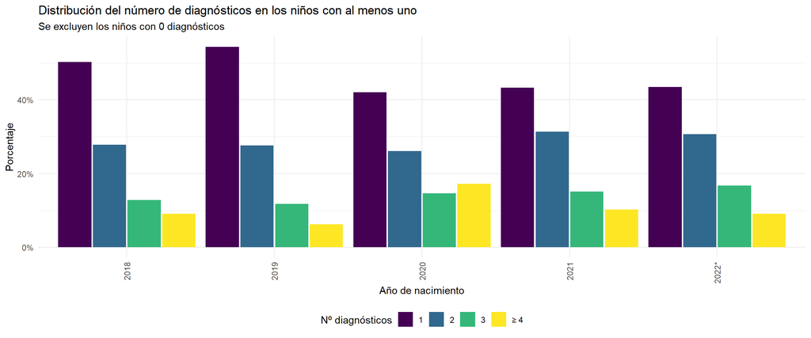

Distribución de niños según diagnóstico (hospitalización) y tipo de lactancia

| tipo_lactancia | 0 diagnósticos | > 0 diagnósticos |
| --- | --- | --- |
| Materna | 23720 (96.55%) | 848 (3.45%) |
| Artificial | 7249 (94.44%) | 427 (5.56%) |
| Mixta | 7550 (96.26%) | 293 (3.74%) |
| NA | 8097 (96.19%) | 321 (3.81%) |

0 diagnósticos = sin infecciones (no hospitalizado) > 0 diagnósticos = con infecciones (hospitalizado)

## 4.2 Base de datos para el objetivo 2

Creación de la base de datos final para el análisis de datos y la inferencia sobre la sostenibilidad del sistema sanitario.

A la base de dato `hospitalización` le añado el nombre de su ZBS usando la base de datos `Códigos de ZBS y provincia`.

Códigos ZBS de la base de datos de `hospitalización` sin correspondencia en la base de datos `Códigos de ZBS y provincia` y valores sin informar.

```
     ZBS frecuencia
1   <NA>        488
2 110800         41
3 110817         15
4 110200          1
5 119902          1
```

Dimensiones de las bases de datos:

```
Hospitalización:
  - Filas:  4991
  - Columnas:  51

 Hospitalización + ZBS:
  - Filas:  4991
  - Columnas:  10

 Hospitalización + ZBS (con ZBS informado):
  - Filas:  4445
  - Columnas:  10
```

Los costes medios APR los hemos obtenidos del [Portal Estadístico](https://pestadistico.inteligenciadegestion.sanidad.gob.es/publicoSNS/C/rae-cmbd/rae-cmbd/grupos-relacionados-por-el-diagnostico-grd/grd-estadisticos-por-comunidad-autonoma-grupo-de-hospitales-servicios).

Ejemplo:

```
  GRD year_ingreso    ZBS CENTRO   CIP_ANON   ZBS_desc Severidad_fct   valor
1 113         2018 110222 130127 2967241511 VALDEPEÑAS         Mayor 3243.38
2 138         2018 110222 130127 2967241511 VALDEPEÑAS         Mayor 3052.19
3 144         2018 110222 130087 2967241511 VALDEPEÑAS      Moderada 2668.23
4 144         2018 110222 130087 2967241511 VALDEPEÑAS      Moderada 2668.23
5 144         2018 110222 130087 2967241511 VALDEPEÑAS      Moderada 2668.23
6 144         2018 110222 130087 2967241511 VALDEPEÑAS      Moderada 2668.23
```